# [MPDW] Tugas Praktikum 6

```r
library(ggplot2)
library(tsibble)
library(tseries)
library(MASS)
library(forecast)
library(TSA)
library(TTR)
library(aTSA)
library(graphics)
```

# Data

## Import Data

```r
library(readxl)
df <- read_excel("D:\\SMT 5\\Metode Peramalan Deret Waktu\\Tugas\\Tugas Praktikum 1\\100 Gugus Data Kelompok.xlsx")
df
```

```
## # A tibble: 100 × 2
##    Date       Monorail_User
##    <chr>              <dbl>
##  1 2023-11-05         45456
##  2 2023-11-06         55950
##  3 2023-11-07         59216
##  4 2023-11-08         59150
##  5 2023-11-09         59143
##  6 2023-11-10         61061
##  7 2023-11-11         58189
##  8 2023-11-12         65967
##  9 2023-11-13         46834
## 10 2023-11-14         55153
## # ℹ 90 more rows
```

```r
df.train <- df$Monorail_User[1:80]
df.test <- df$Monorail_User[81:100]
```

## Eksplorasi Data

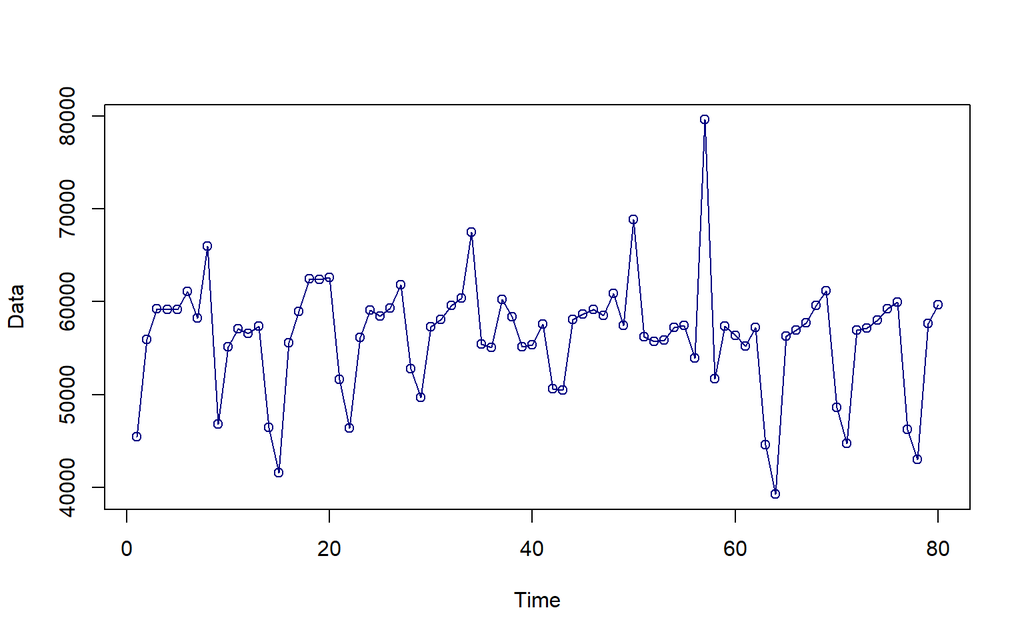

```r
plot(df.train,
     col = "navyblue",
     lwd = 1,
     type = "o",
     xlab = "Time",
     ylab = "Data")
```

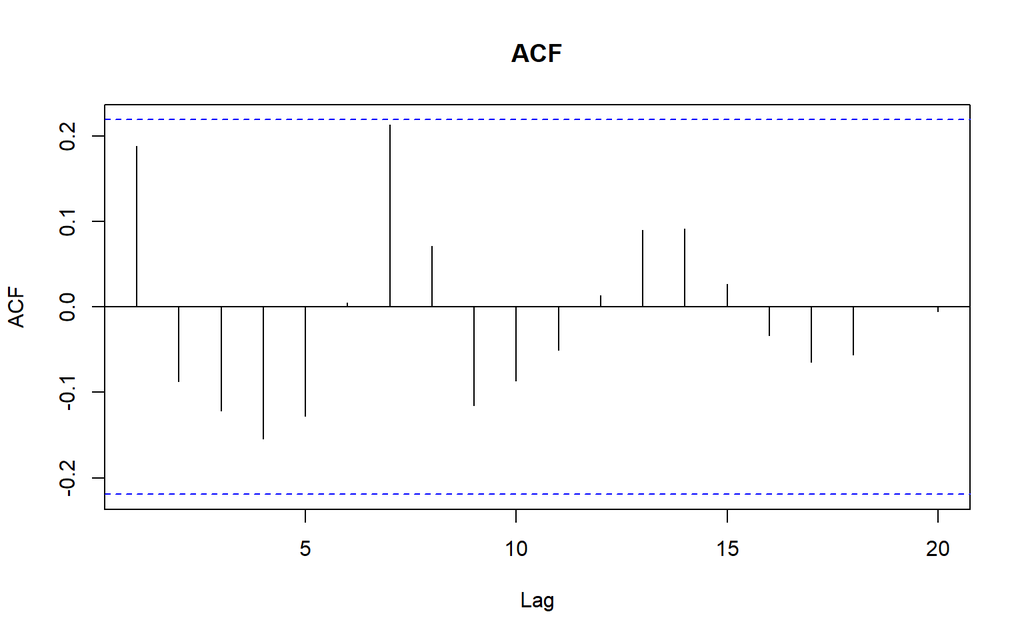

```r
acf(df.train, main="ACF", lag.max=20)
```

```r
tseries::adf.test(df.train)
```

```
##
##  Augmented Dickey-Fuller Test
##
## data:  df.train
## Dickey-Fuller = -4.8659, Lag order = 4, p-value = 0.01
## alternative hypothesis: stationary
```

$H_0$ : Data tidak stasioner dalam rataan

$H_1$ : Data stasioner dalam rataan

Berdasarkan uji ADF tersebut, didapat p-value sebesar 0.01 yang lebih kecil dari taraf nyata 5% sehingga tolak $H_0$ dan menandakan bahwa data stasioner dalam rataan

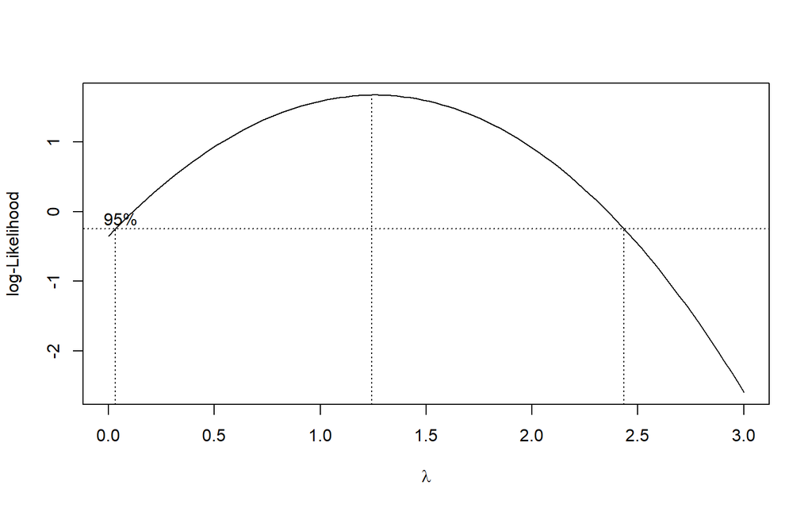

```r
index <- seq(1:80)

# Box-Cox
bc <- boxcox(
  df.train~index,
  lambda = seq(0, 3, by = 1)
)
```

```r
# Nilai lambda optimum
lambda <- bc$x[which.max(bc$y)]
lambda
```

```
## [1] 1.242424
```

```r
# Selang kepercayaan 95% untuk lambda
ci_lambda <- bc$x[bc$y > max(bc$y) - 0.5 * qchisq(0.95, 1)]

# Batas bawah dan batas atas
ci_lower <- min(ci_lambda)
ci_upper <- max(ci_lambda)

c(Batas_Bawah = ci_lower, Batas_Atas = ci_upper)
```

```
## Batas_Bawah  Batas_Atas
##  0.06060606  2.42424242
```

Gambar di atas menunjukkan nilai rounded value ($\lambda$) optimum sebesar 1,24 dan pada selang kepercayaan 95% nilai memiliki batas bawah 0,06 dan batas atas 2,42. Selang tersebut memuat nilai satu sehingga dapat dikatakan bahwa data bangkitan stasioner dalam ragam.

## Spesifikasi Model

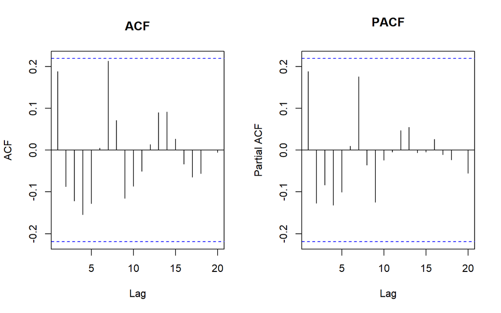

```r
#---SPESIFIKASI MODEL---#
par(mfrow = c(1,2))
acf(df.train, main="ACF", lag.max=20) #ARIMA(0,0,2)
pacf(df.train, main="PACF", lag.max=20) #ARIMA(1,0,0)
```

```r
eacf(df.train)
```

```
## AR/MA
##   0 1 2 3 4 5 6 7 8 9 10 11 12 13
## 0 o o o o o o o o o o o  o  o  o
## 1 x o o o o o x o o o o  o  o  o
## 2 x o o o o o o o o o o  o  o  o
## 3 x x o o o o o o o o o  o  o  o
## 4 x x o o o o o o o o o  o  o  o
## 5 o o o o o o o o o o o  o  o  o
## 6 o x x o o x o o o o o  o  o  o
## 7 o x x o o x o o o o o  o  o  o
```

Berdasarkan plot EACF model tentatif yang terbentuk adalah ARIMA(1,0,7), ARIMA(2,0,1), dan ARIMA(3,0,2)

## Pendugaan Parameter

```r
model_107 <- Arima(df.train, order = c(1,0,7), method = "ML")
lmtest::coeftest(model_107)
```

```
##
## z test of coefficients:
##
##              Estimate  Std. Error z value Pr(>|z|)
## ar1        3.2327e-01  4.0363e-01  0.8009   0.4232
## ma1       -1.4452e-01  3.9448e-01 -0.3663   0.7141
## ma2       -8.6997e-02  1.3444e-01 -0.6471   0.5176
## ma3       -5.1275e-02  1.2260e-01 -0.4182   0.6758
## ma4       -1.3352e-01  1.1448e-01 -1.1663   0.2435
## ma5       -1.3277e-01  1.2934e-01 -1.0265   0.3046
## ma6       -3.5258e-02  1.3453e-01 -0.2621   0.7933
## ma7        2.2592e-01  1.1827e-01  1.9102   0.0561 .
## intercept  5.6350e+04  6.0923e+02 92.4928   <2e-16 ***
## ---
## Signif. codes:  0 '***' 0.001 '**' 0.01 '*' 0.05 '.' 0.1 ' ' 1
```

```r
model_201 <- Arima(df.train, order = c(2,0,1), method = "ML")
lmtest::coeftest(model_201)
```

```
##
## z test of coefficients:
##
##              Estimate  Std. Error  z value  Pr(>|z|)
## ar1           0.88144     0.27025   3.2615  0.001108 **
## ar2          -0.27660     0.11000  -2.5146  0.011917 *
## ma1          -0.68155     0.26509  -2.5710  0.010142 *
## intercept 56359.62108   543.49800 103.6979 < 2.2e-16 ***
## ---
## Signif. codes:  0 '***' 0.001 '**' 0.01 '*' 0.05 '.' 0.1 ' ' 1
```

```r
model_302 <- Arima(df.train, order = c(3,0,2), method = "ML")
lmtest::coeftest(model_302)
```

```
##
## z test of coefficients:
##
##              Estimate  Std. Error  z value  Pr(>|z|)
## ar1       -8.6184e-02  2.7419e-01  -0.3143  0.753272
## ar2        5.8405e-01  2.4929e-01   2.3428  0.019138 *
## ar3       -2.5729e-01  1.1362e-01  -2.2645  0.023543 *
## ma1        3.0840e-01  2.6724e-01   1.1540  0.248490
## ma2       -6.9158e-01  2.6574e-01  -2.6024  0.009257 **
## intercept  5.6356e+04  5.4358e+02 103.6760 < 2.2e-16 ***
## ---
## Signif. codes:  0 '***' 0.001 '**' 0.01 '*' 0.05 '.' 0.1 ' ' 1
```

```r
hasil_eacf <- data.frame(
  Model = c("ARIMA(1,0,7)",
            "ARIMA(2,0,1)",
            "ARIMA(3,0,2)"),
  AIC = c(AIC(model_107),
          AIC(model_201),
          AIC(model_302)),
  BIC = c(BIC(model_107),
          BIC(model_201),
          BIC(model_302))
)

hasil_eacf
```

```
##          Model      AIC      BIC
## 1 ARIMA(1,0,7) 1632.538 1656.358
## 2 ARIMA(2,0,1) 1626.747 1638.657
## 3 ARIMA(3,0,2) 1630.254 1646.928
```

Berdasarkan hasil perbandingan model tentatif, ARIMA(2,0,1) memiliki nilai AIC dan BIC terkecil dibandingkan model lainnya. Selain itu, seluruh parameter pada model ARIMA(2,0,1) signifikan. Oleh karena itu, ARIMA(2,0,1) dipilih sebagai model terpilih sementara untuk tahap analisis sisaan dan overfitting

## Analisis Sisaan

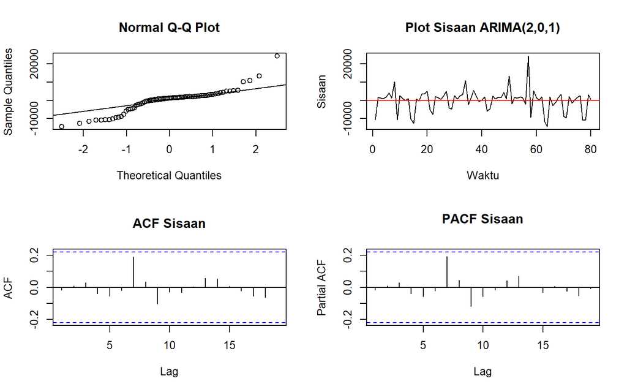

```r
# Sisaan model ARIMA(2,0,1)
sisaan_201 <- residuals(model_201)

# Plot diagnostik sisaan
par(mfrow = c(2,2))

# Q-Q Plot
qqnorm(sisaan_201)
qqline(sisaan_201)

# Sisaan terhadap waktu
plot(sisaan_201, type = "l",
     main = "Plot Sisaan ARIMA(2,0,1)",
     xlab = "Waktu",
     ylab = "Sisaan")
abline(h = 0, col = "red")

# ACF sisaan
acf(sisaan_201, main = "ACF Sisaan")

# PACF sisaan
pacf(sisaan_201, main = "PACF Sisaan")
```

```r
par(mfrow = c(1,1))
```

```r
ks.test(
  sisaan_201,
  "pnorm",
  mean = mean(sisaan_201),
  sd = sd(sisaan_201)
)
```

```
##
##  Exact one-sample Kolmogorov-Smirnov test
##
## data:  sisaan_201
## D = 0.18657, p-value = 0.006539
## alternative hypothesis: two-sided
```

```r
Box.test(
  sisaan_201,
  lag = 1,
  type = "Ljung-Box"
)
```

```
##
##  Box-Ljung test
##
## data:  sisaan_201
## X-squared = 0.021351, df = 1, p-value = 0.8838
```

```r
Box.test(
  sisaan_201^2,
  lag = 1,
  type = "Ljung-Box"
)
```

```
##
##  Box-Ljung test
##
## data:  sisaan_201^2
## X-squared = 0.90542, df = 1, p-value = 0.3413
```

```r
t.test(sisaan_201, mu = 0)
```

```
##
##  One Sample t-test
##
## data:  sisaan_201
## t = -0.0055682, df = 79, p-value = 0.9956
## alternative hypothesis: true mean is not equal to 0
## 95 percent confidence interval:
##  -1327.699  1320.292
## sample estimates:
## mean of x
## -3.703826
```

Berdasarkan hasil analisis sisaan model ARIMA(2,0,1), uji Kolmogorov-Smirnov menghasilkan p-value sebesar 0,006539 < 0,05 sehingga **sisaan tidak berdistribusi normal.** Uji Ljung-Box pada sisaan menghasilkan p-value sebesar 0,8838 > 0,05 sehingga **tidak terdapat autokorelasi yang signifikan.** Uji Ljung-Box pada sisaan kuadrat menghasilkan p-value sebesar 0,3413 > 0,05 sehingga **tidak terdapat efek ARCH.** Selanjutnya, uji t menghasilkan p-value sebesar 0,9956 > 0,05 sehingga **rataan sisaan tidak berbeda signifikan dari nol.** Dengan demikian, sisaan model ARIMA(2,0,1) **tidak memenuhi asumsi normalitas, tetapi telah memenuhi asumsi independensi, ragam konstan, dan rataan nol.**

## Overfitting

Tahapan selanjutnya adalah overfitting dilakukan dengan menaikkan orde AR(p) dan MA(q) dari model ARIMA(2,0,1) untuk melihat apakah terdapat model lain yang lebih baik dari model saat ini. Kandidat model overfitting adalah ARIMA(2,0,2) dan ARIMA(3,0,1).

```r
model_202 <- Arima(df.train, order = c(2,0,2), method = "ML")
lmtest::coeftest(model_202)
```

```
##
## z test of coefficients:
##
##              Estimate  Std. Error z value  Pr(>|z|)
## ar1           1.15299     0.14127  8.1617 3.303e-16 ***
## ar2          -0.89734     0.11733 -7.6477 2.045e-14 ***
## ma1          -1.01316     0.19830 -5.1093 3.234e-07 ***
## ma2           0.74874     0.16193  4.6237 3.769e-06 ***
## intercept 56375.48386   645.69737 87.3095 < 2.2e-16 ***
## ---
## Signif. codes:  0 '***' 0.001 '**' 0.01 '*' 0.05 '.' 0.1 ' ' 1
```

```r
model_301 <- Arima(df.train, order = c(3,0,1), method = "ML")
lmtest::coeftest(model_301)
```

```
##
## z test of coefficients:
##
##              Estimate  Std. Error  z value Pr(>|z|)
## ar1           0.78492     0.37277   2.1056  0.03524 *
## ar2          -0.22855     0.16512  -1.3842  0.16631
## ar3          -0.05506     0.14388  -0.3827  0.70196
## ma1          -0.59306     0.35851  -1.6542  0.09809 .
## intercept 56361.81771   547.94025 102.8612  < 2e-16 ***
## ---
## Signif. codes:  0 '***' 0.001 '**' 0.01 '*' 0.05 '.' 0.1 ' ' 1
```

```r
overfitting <- data.frame(
  Model = c("ARIMA(2,0,1)",
            "ARIMA(2,0,2)",
            "ARIMA(3,0,1)"),
  AIC = c(AIC(model_201),
          AIC(model_202),
          AIC(model_301)),
  BIC = c(BIC(model_201),
          BIC(model_202),
          BIC(model_301))
)

overfitting
```

```
##          Model      AIC      BIC
## 1 ARIMA(2,0,1) 1626.747 1638.657
## 2 ARIMA(2,0,2) 1626.709 1641.002
## 3 ARIMA(3,0,1) 1628.612 1642.904
```

Hasil overfitting menunjukkan bahwa ARIMA(2,0,2) dan ARIMA(3,0,1) tidak memberikan peningkatan yang cukup dibandingkan ARIMA(2,0,1). ARIMA(2,0,2) memiliki AIC yang sedikit lebih kecil, tetapi BIC lebih besar, sedangkan ARIMA(3,0,1) memiliki AIC dan BIC lebih besar serta tidak seluruh parameternya signifikan. Oleh karena itu, model ARIMA(2,0,1) tetap dipertahankan sebagai model terpilih

# Forecasting

```r
ramalan <- forecast::forecast(model_201, h = 20)
ramalan
```

```
##     Point Forecast    Lo 80    Hi 80    Lo 95    Hi 95
##  81       58585.12 50811.50 66358.73 46696.40 70473.84
##  82       57407.55 49480.15 65334.96 45283.63 69531.47
##  83       56667.74 48702.00 64633.47 44485.20 68850.28
##  84       56341.35 48297.57 64385.13 44039.45 68643.25
##  85       56258.29 48177.80 64338.78 43900.25 68616.33
##  86       56275.36 48186.45 64364.27 43904.44 68646.28
##  87       56313.38 48223.69 64403.07 43941.26 68685.49
##  88       56342.17 48252.48 64431.86 43970.05 68714.28
##  89       56357.03 48267.27 64446.79 43984.80 68729.25
##  90       56362.16 48272.35 64451.98 43989.86 68734.46
##  91       56362.58 48272.75 64452.41 43990.25 68734.90
##  92       56361.53 48271.69 64451.36 43989.20 68733.85
##  93       56360.48 48270.65 64450.31 43988.15 68732.81
##  94       56359.85 48270.02 64449.68 43987.52 68732.18
##  95       56359.59 48269.76 64449.42 43987.26 68731.92
##  96       56359.53 48269.70 64449.36 43987.20 68731.86
##  97       56359.55 48269.72 64449.38 43987.22 68731.88
##  98       56359.58 48269.75 64449.41 43987.25 68731.91
##  99       56359.61 48269.78 64449.44 43987.28 68731.94
## 100       56359.62 48269.79 64449.45 43987.29 68731.95
```

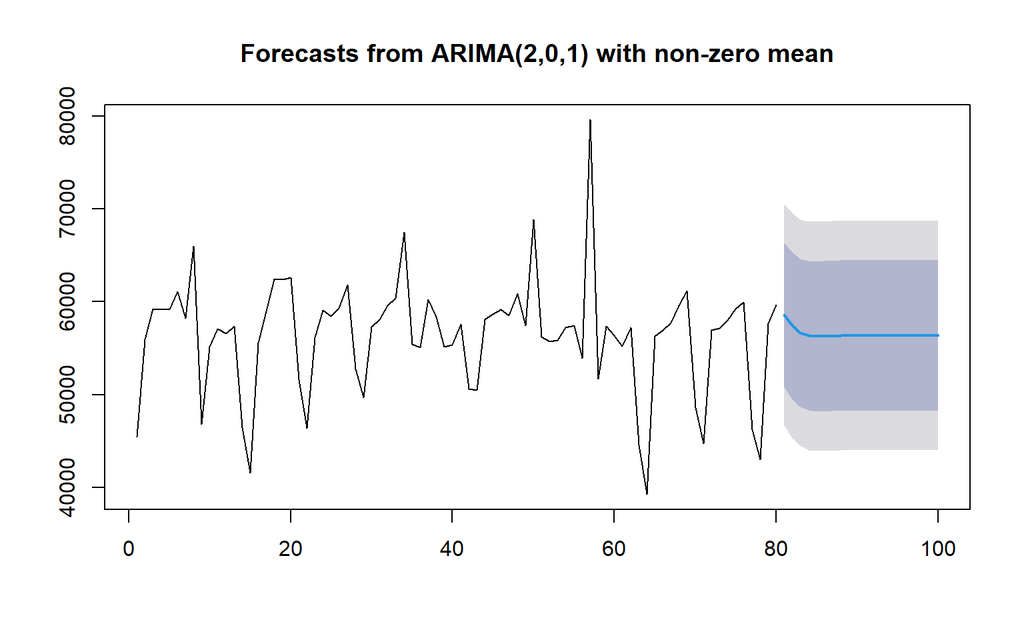

```r
data.ramalan <- ramalan$mean
plot(ramalan)
```

Berdasarkan hasil plot ramalan di atas, dapat dilihat bahwa ramalan ARIMA(2,0,1) cenderung menurun di awal periode dan stabil hingga akhir periode. Selanjutnya, dapat dicari nilai akurasi antara hasil ramalan dengan data uji sebagai berikut

```r
perbandingan<-matrix(data=c(df.test, data.ramalan),
                     nrow = 20, ncol = 2)
colnames(perbandingan)<-c("Aktual","Hasil Forecast")
perbandingan
```

```
##       Aktual Hasil Forecast
##  [1,]  62053       58585.12
##  [2,]  41704       57407.55
##  [3,]  59550       56667.74
##  [4,]  47548       56341.35
##  [5,]  42535       56258.29
##  [6,]  59158       56275.36
##  [7,]  59925       56313.38
##  [8,]  63215       56342.17
##  [9,]  38708       56357.03
## [10,]  59159       56362.16
## [11,]  53502       56362.58
## [12,]  46048       56361.53
## [13,]  58095       56360.48
## [14,]  59472       56359.85
## [15,]  61496       56359.59
## [16,]  58465       56359.53
## [17,]  59148       56359.55
## [18,]  68149       56359.58
## [19,]  70687       56359.61
## [20,]  50706       56359.62
```

```r
# Akurasi
accuracy(data.ramalan, df.test)
```

```
##                 ME     RMSE      MAE       MPE     MAPE
## Test set -559.4523 8551.466 6910.242 -3.675898 13.61421
```

```r
data.aktual <- c(df.train, df.test)
```

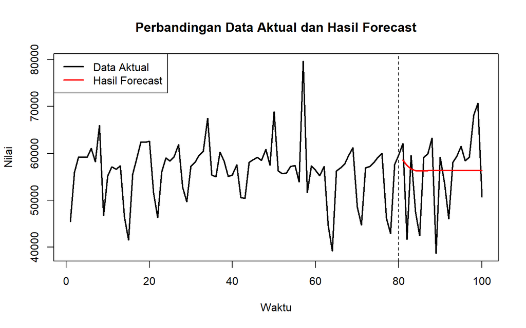

```r
plot(data.aktual,
     type = "l",
     col = "black",
     lwd = 2,
     xlab = "Waktu",
     ylab = "Nilai",
     main = "Perbandingan Data Aktual dan Hasil Forecast")

# Hasil forecast
lines(
  (length(df.train) + 1):(length(df.train) + 20),
  as.numeric(ramalan$mean),
  col = "red",
  lwd = 2
)

# Batas data train dan test
abline(
  v = length(df.train),
  lty = 2
)

legend(
  "topleft",
  legend = c("Data Aktual", "Hasil Forecast"),
  col = c("black", "red"),
  lty = 1,
  lwd = 2
)
```